# chapter5

Matthias Aulbach

20 Februar 2017

# Week 5

## Loading exploring the data

The “human” dataset consists of 8 variables that describe different aspects of human development with a strong emphasis on equality between men and women. The variables indexing equality are mainly the share of women with secondary education compared to men (“Edu2.FM”), the proportion of women in the labor force compared to proportion of men in the laborforce (“Labo.FM”), and the share of female members of parliament (“Parli.F”).

## Summary and overview

```r
summary(human)
```

```
##     Edu2.FM          Labo.FM          Edu.Exp         Life.Exp
##  Min.   :0.1717   Min.   :0.1857   Min.   : 5.40   Min.   :49.00
##  1st Qu.:0.7264   1st Qu.:0.5984   1st Qu.:11.25   1st Qu.:66.30
##  Median :0.9375   Median :0.7535   Median :13.50   Median :74.20
##  Mean   :0.8529   Mean   :0.7074   Mean   :13.18   Mean   :71.65
##  3rd Qu.:0.9968   3rd Qu.:0.8535   3rd Qu.:15.20   3rd Qu.:77.25
##  Max.   :1.4967   Max.   :1.0380   Max.   :20.20   Max.   :83.50
##       GNI            Mat.Mor         Ado.Birth         Parli.F
##  Min.   :   581   Min.   :   1.0   Min.   :  0.60   Min.   : 0.00
##  1st Qu.:  4198   1st Qu.:  11.5   1st Qu.: 12.65   1st Qu.:12.40
##  Median : 12040   Median :  49.0   Median : 33.60   Median :19.30
##  Mean   : 17628   Mean   : 149.1   Mean   : 47.16   Mean   :20.91
##  3rd Qu.: 24512   3rd Qu.: 190.0   3rd Qu.: 71.95   3rd Qu.:27.95
##  Max.   :123124   Max.   :1100.0   Max.   :204.80   Max.   :57.50
```

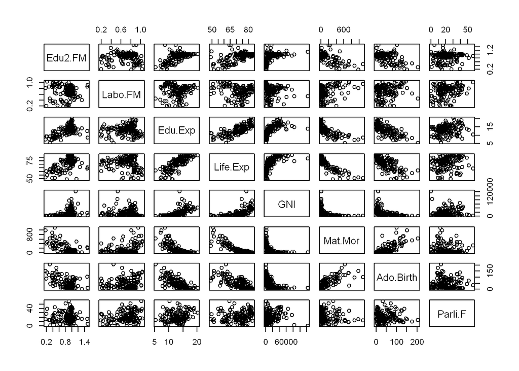

```r
pairs(human)
```

```r
cor_matrix <- cor(human) %>% round (digits = 2)
cor_matrix
```

```
##           Edu2.FM Labo.FM Edu.Exp Life.Exp   GNI Mat.Mor Ado.Birth Parli.F
## Edu2.FM      1.00    0.01    0.59     0.58  0.43   -0.66     -0.53    0.08
## Labo.FM      0.01    1.00    0.05    -0.14 -0.02    0.24      0.12    0.25
## Edu.Exp      0.59    0.05    1.00     0.79  0.62   -0.74     -0.70    0.21
## Life.Exp     0.58   -0.14    0.79     1.00  0.63   -0.86     -0.73    0.17
## GNI          0.43   -0.02    0.62     0.63  1.00   -0.50     -0.56    0.09
## Mat.Mor     -0.66    0.24   -0.74    -0.86 -0.50    1.00      0.76   -0.09
## Ado.Birth   -0.53    0.12   -0.70    -0.73 -0.56    0.76      1.00   -0.07
## Parli.F      0.08    0.25    0.21     0.17  0.09   -0.09     -0.07    1.00
```

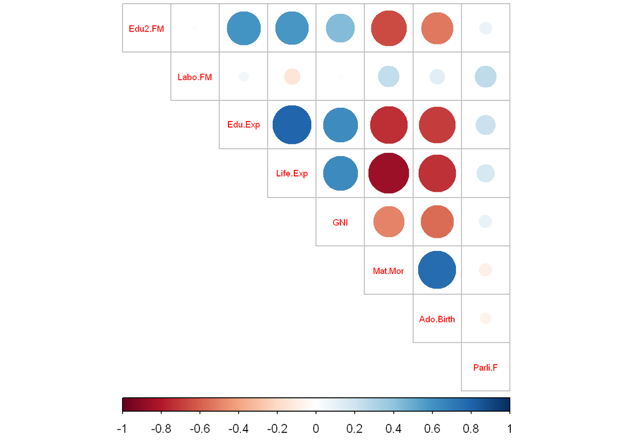

```r
corrplot(cor_matrix, method="circle", type = "upper", cl.pos = "b", tl.pos = "d", tl.cex = 0.6)
```

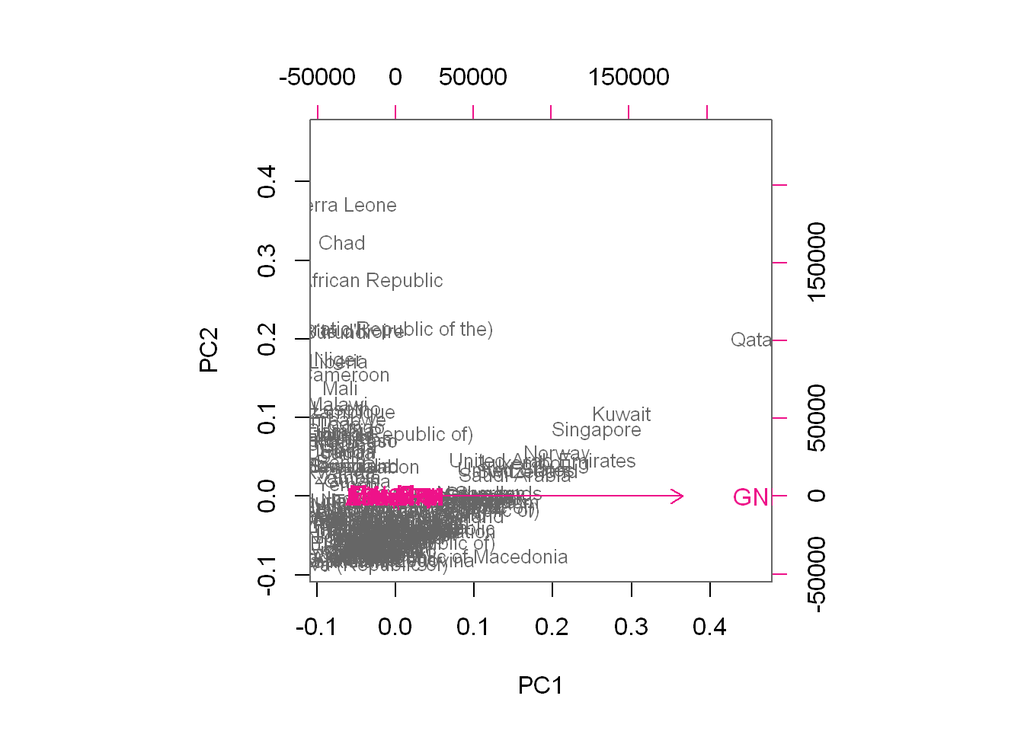

```r
pca_human <- prcomp(human)
biplot(pca_human, choices = 1:2, cex = c(0.8, 1), col = c("grey40", "deeppink2"))
```

```r
s <- summary(pca_human)
s
```

```
## Importance of components:
##                              PC1      PC2   PC3   PC4   PC5   PC6    PC7
## Standard deviation     1.854e+04 185.5219 25.19 11.45 3.766 1.566 0.1912
## Proportion of Variance 9.999e-01   0.0001  0.00  0.00 0.000 0.000 0.0000
## Cumulative Proportion  9.999e-01   1.0000  1.00  1.00 1.000 1.000 1.0000
##                           PC8
## Standard deviation     0.1591
## Proportion of Variance 0.0000
## Cumulative Proportion  1.0000
```

```r
pca_pr <- round(100*s$importance[2, ], digits = 1)
pca_pr
```

```
## PC1 PC2 PC3 PC4 PC5 PC6 PC7 PC8
## 100   0   0   0   0   0   0   0
```

```r
paste0(names(pca_pr), " (", pca_pr, "%)")
```

```
## [1] "PC1 (100%)" "PC2 (0%)"   "PC3 (0%)"   "PC4 (0%)"   "PC5 (0%)"
## [6] "PC6 (0%)"   "PC7 (0%)"   "PC8 (0%)"
```

```r
pc_lab <- paste0(names(pca_pr), " (", pca_pr, "%)")
pc_lab
```

```
## [1] "PC1 (100%)" "PC2 (0%)"   "PC3 (0%)"   "PC4 (0%)"   "PC5 (0%)"
## [6] "PC6 (0%)"   "PC7 (0%)"   "PC8 (0%)"
```

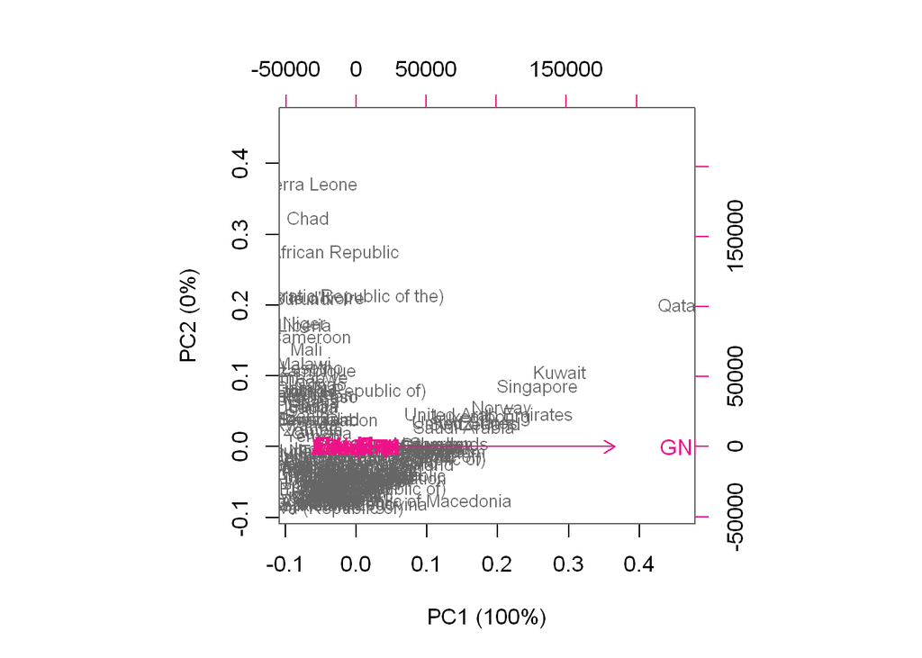

```r
# draw a biplot
biplot(pca_human, cex = c(0.8, 1), col = c("grey40", "deeppink2"), xlab = pc_lab[1], ylab = pc_lab[2])
```

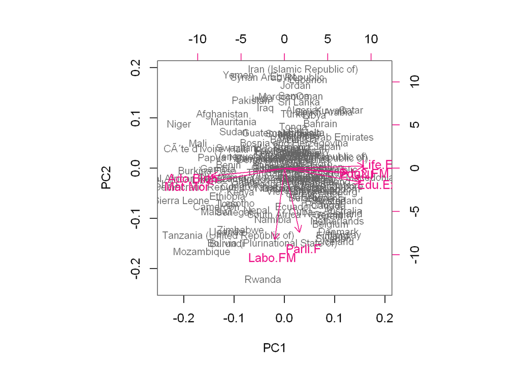

```r
human <- scale (human)
pca_human <- prcomp(human)
biplot(pca_human, choices = 1:2, cex = c(0.8, 1), col = c("grey40", "deeppink2"))
```

```r
s <- summary(pca_human)
s
```

```
## Importance of components:
##                           PC1    PC2     PC3     PC4     PC5     PC6
## Standard deviation     2.0708 1.1397 0.87505 0.77886 0.66196 0.53631
## Proportion of Variance 0.5361 0.1624 0.09571 0.07583 0.05477 0.03595
## Cumulative Proportion  0.5361 0.6984 0.79413 0.86996 0.92473 0.96069
##                            PC7     PC8
## Standard deviation     0.45900 0.32224
## Proportion of Variance 0.02634 0.01298
## Cumulative Proportion  0.98702 1.00000
```

```r
pca_pr <- round(100*s$importance[2, ], digits = 1)
pca_pr
```

```
##  PC1  PC2  PC3  PC4  PC5  PC6  PC7  PC8
## 53.6 16.2  9.6  7.6  5.5  3.6  2.6  1.3
```

```r
paste0(names(pca_pr), " (", pca_pr, "%)")
```

```
## [1] "PC1 (53.6%)" "PC2 (16.2%)" "PC3 (9.6%)"  "PC4 (7.6%)"  "PC5 (5.5%)"
## [6] "PC6 (3.6%)"  "PC7 (2.6%)"  "PC8 (1.3%)"
```

```r
pc_lab <- paste0(names(pca_pr), " (", pca_pr, "%)")
pc_lab
```

```
## [1] "PC1 (53.6%)" "PC2 (16.2%)" "PC3 (9.6%)"  "PC4 (7.6%)"  "PC5 (5.5%)"
## [6] "PC6 (3.6%)"  "PC7 (2.6%)"  "PC8 (1.3%)"
```

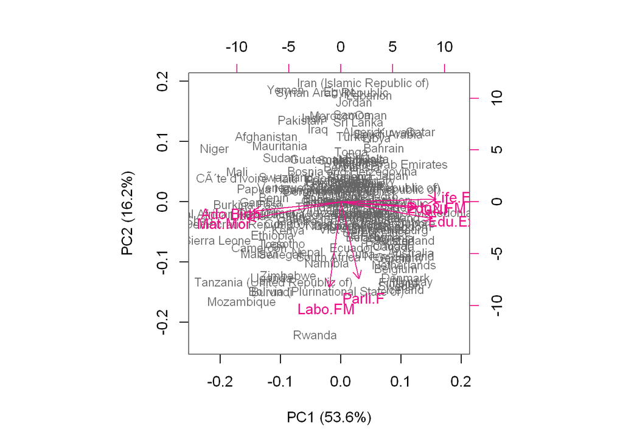

```r
# draw a biplot
biplot(pca_human, cex = c(0.8, 1), col = c("grey40", "deeppink2"), xlab = pc_lab[1], ylab = pc_lab[2])
```

After standardizing the data, the analysis makes much more sense. We can see that PC1 accounts for 53.6% of the variance and PC2 for 16.2%. We can also see that all variables but *Labo.FM* and *Parli.F* differentiate between countries on the PC1 dimension. *Labo.FM* and *Parli.F* differentiate on the PC 2 dimension and are correlated: the proportion of women in the workforce and the share of female MPs. This indicates that we can differentiate between countries in regard to their representation of women in the labor market and parliament on the one hand, and all other variables in the dataset on the other hand. We might therefore consider PC2 as “female representation” and PC1 as “health and education development”.

## Tea dataset

```r
library(FactoMineR)
library(tidyr)
library(dplyr)
data(tea)
str(tea)
```

```
## 'data.frame':    300 obs. of  36 variables:
##  $ breakfast       : Factor w/ 2 levels "breakfast","Not.breakfast": 1 1 2 2 1 2 1 2 1 1 ...
##  $ tea.time        : Factor w/ 2 levels "Not.tea time",..: 1 1 2 1 1 1 2 2 2 1 ...
##  $ evening         : Factor w/ 2 levels "evening","Not.evening": 2 2 1 2 1 2 2 1 2 1 ...
##  $ lunch           : Factor w/ 2 levels "lunch","Not.lunch": 2 2 2 2 2 2 2 2 2 2 ...
##  $ dinner          : Factor w/ 2 levels "dinner","Not.dinner": 2 2 1 1 2 1 2 2 2 2 ...
##  $ always          : Factor w/ 2 levels "always","Not.always": 2 2 2 2 1 2 2 2 2 2 ...
##  $ home            : Factor w/ 2 levels "home","Not.home": 1 1 1 1 1 1 1 1 1 1 ...
##  $ work            : Factor w/ 2 levels "Not.work","work": 1 1 2 1 1 1 1 1 1 1 ...
##  $ tearoom         : Factor w/ 2 levels "Not.tearoom",..: 1 1 1 1 1 1 1 1 1 2 ...
##  $ friends         : Factor w/ 2 levels "friends","Not.friends": 2 2 1 2 2 2 1 2 2 2 ...
##  $ resto           : Factor w/ 2 levels "Not.resto","resto": 1 1 2 1 1 1 1 1 1 1 ...
##  $ pub             : Factor w/ 2 levels "Not.pub","pub": 1 1 1 1 1 1 1 1 1 1 ...
##  $ Tea             : Factor w/ 3 levels "black","Earl Grey",..: 1 1 2 2 2 2 2 1 2 1 ...
##  $ How             : Factor w/ 4 levels "alone","lemon",..: 1 3 1 1 1 1 1 3 3 1 ...
```

[output cut: 22 more lines]

```r
dim(tea)
```

```
## [1] 300  36
```

The “tea” dataset contains 300 observations of 36 variables indicating participants’ habits concerning tea consumption (How British!). I will focus on a few key variables here that I find interesting: “effect.on.health”, “relaxing”, “exciting”, “slimming”, and “sophisticated” since I’m interested in why people drink tea.

```r
keep <- c("effect.on.health", "relaxing", "exciting", "slimming", "sophisticated")
tea <- dplyr::select(tea, one_of(keep))
str(tea)
```

```
## 'data.frame':    300 obs. of  5 variables:
##  $ effect.on.health: Factor w/ 2 levels "effect on health",..: 2 2 2 2 2 2 2 2 2 2 ...
##  $ relaxing        : Factor w/ 2 levels "No.relaxing",..: 1 1 2 2 2 2 2 2 2 2 ...
##  $ exciting        : Factor w/ 2 levels "exciting","No.exciting": 2 1 2 2 2 2 2 2 2 2 ...
##  $ slimming        : Factor w/ 2 levels "No.slimming",..: 1 1 1 1 1 1 1 1 1 1 ...
##  $ sophisticated   : Factor w/ 2 levels "Not.sophisticated",..: 1 1 1 2 1 1 1 2 2 1 ...
```

```r
dim(tea)
```

```
## [1] 300   5
```

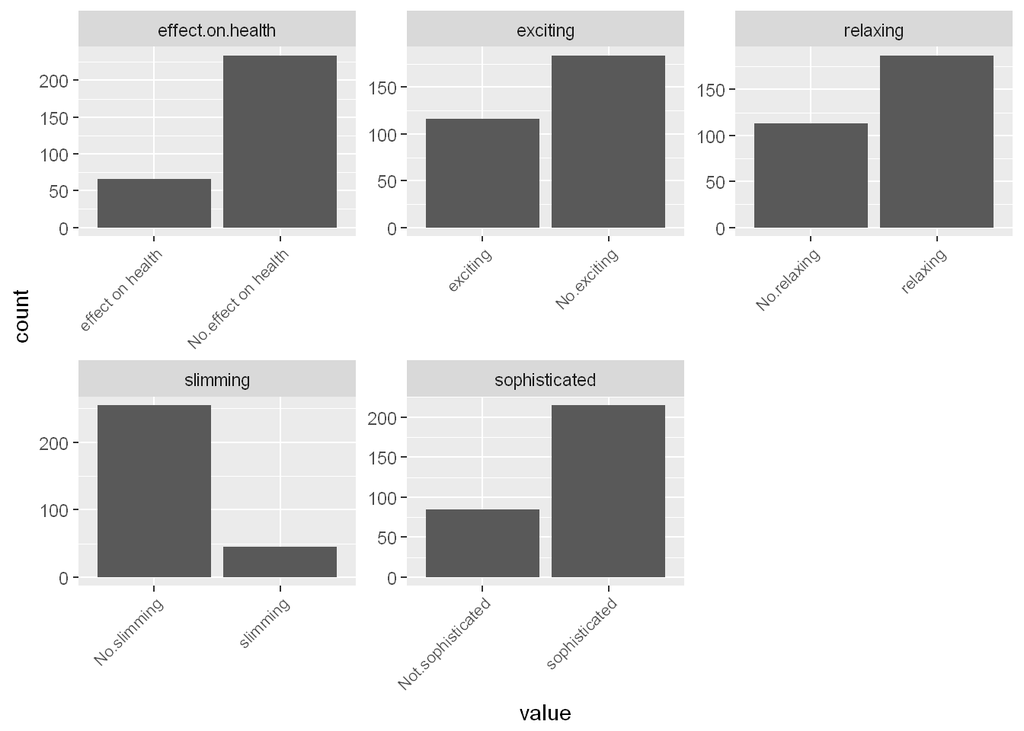

```r
gather(tea) %>% ggplot(aes(value)) + geom_bar() + theme(axis.text.x = element_text(angle = 45, hjust = 1, size = 8)) + facet_wrap("key", scales = "free")
```

We can see here that most people think it’s sophisticated, and relaxing. Most people don’t find it exciting, expect an effect on health or think it is slimming.

## Dimension of tea

```r
mca <- MCA(tea, graph = FALSE)
summary(mca)
```

```
##
## Call:
## MCA(X = tea, graph = FALSE)
##
##
## Eigenvalues
##                        Dim.1   Dim.2   Dim.3   Dim.4   Dim.5
## Variance               0.258   0.222   0.209   0.178   0.133
## % of var.             25.816  22.198  20.912  17.804  13.271
## Cumulative % of var.  25.816  48.013  68.925  86.729 100.000
##
## Individuals (the 10 first)
##                        Dim.1    ctr   cos2    Dim.2    ctr   cos2    Dim.3
## 1                   | -0.044  0.002  0.002 | -0.869  1.135  0.717 |  0.200
## 2                   |  0.567  0.415  0.258 | -0.809  0.984  0.526 | -0.136
## 3                   | -0.641  0.531  0.487 | -0.494  0.367  0.289 |  0.206
## 4                   | -0.541  0.377  0.700 |  0.160  0.038  0.061 | -0.236
## 5                   | -0.641  0.531  0.487 | -0.494  0.367  0.289 |  0.206
## 6                   | -0.641  0.531  0.487 | -0.494  0.367  0.289 |  0.206
## 7                   | -0.641  0.531  0.487 | -0.494  0.367  0.289 |  0.206
## 8                   | -0.541  0.377  0.700 |  0.160  0.038  0.061 | -0.236
## 9                   | -0.541  0.377  0.700 |  0.160  0.038  0.061 | -0.236
## 10                  | -0.641  0.531  0.487 | -0.494  0.367  0.289 |  0.206
##                        ctr   cos2
## 1                    0.064  0.038 |
## 2                    0.029  0.015 |
## 3                    0.067  0.050 |
## 4                    0.089  0.133 |
## 5                    0.067  0.050 |
## 6                    0.067  0.050 |
## 7                    0.067  0.050 |
## 8                    0.089  0.133 |
## 9                    0.089  0.133 |
## 10                   0.067  0.050 |
##
## Categories
##                         Dim.1     ctr    cos2  v.test     Dim.2     ctr
## effect on health    |   0.650   7.196   0.119   5.967 |   0.229   1.043
## No.effect on health |  -0.183   2.030   0.119  -5.967 |  -0.065   0.294
## No.relaxing         |   0.946  26.098   0.540  12.712 |  -0.551  10.308
```

[output cut: 11 more lines]

```
## relaxing              0.184   7.408 |   0.005   0.002   0.000   0.115 |
## exciting              0.005   1.190 |  -0.470   8.176   0.139  -6.456 |
## No.exciting           0.005  -1.190 |   0.296   5.155   0.139   6.456 |
## No.slimming           0.425 -11.274 |  -0.160   2.076   0.145  -6.578 |
## slimming              0.425  11.274 |   0.906  11.765   0.145   6.578 |
## Not.sophisticated     0.482 -12.001 |   0.724  14.196   0.207   7.869 |
## sophisticated         0.482  12.001 |  -0.286   5.612   0.207  -7.869 |
##
## Categorical variables (eta2)
##                       Dim.1 Dim.2 Dim.3
## effect.on.health    | 0.119 0.015 0.554 |
## relaxing            | 0.540 0.184 0.000 |
## exciting            | 0.571 0.005 0.139 |
## slimming            | 0.047 0.425 0.145 |
## sophisticated       | 0.013 0.482 0.207 |
```

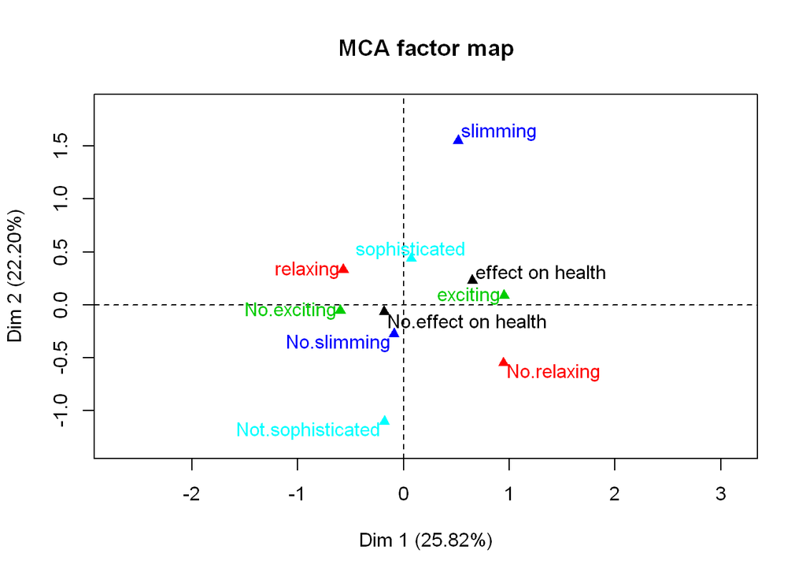

```r
plot(mca, invisible=c("ind"), habillage = "quali")
```

From the Multiple Correspondence Analysis, we infer that the items seem indeed to refer to different dimensions, indicated by the fact that the Eigenvalues of the dimensions are of comparable size for all five dimensions. In the plot of the first two dimensions, we can see that “slimming” is somewhat of an outlier and - to a fewer extent - “not sophisticated”. The other items group around 0. So while these two dimensions might in fact differentiate between “slimming” and “non-slimming”, and “sophisiticated” and “not sophisticated”, they can barely distinguish between the other items.